# Module 6: Data Visualizations in R

## **Introduction**

In this tutorial, we learn how to visualize the data using package “ggplot2”. Although R has several functions for creating visualizations, package “ggplot2” is widely used for creating aesthetic visualizations in R. “ggplot2” implements the **grammar of graphics**, a coherent system for describing and building graphs.

We first need to load the library:

```r
library(ggplot2)
```

*Note: If we need to be explicit about where a function (or dataset) comes from, we’ll use the special form `package::function()`. For example, `ggplot2::ggplot()` tells us explicitly that we’re using the `ggplot()` function from the “ggplot2” package.*

In this module, we use salary data set we have used in the previous modules:

```r
salary <- read.csv("salary_data.csv", strip.white = T, na.strings = "?")

# View the first 6 rows of data
head(salary)
```

|  | age | workclass | fnlwgt | education | education.num | martital.status | occupation | relationship | race | sex | capital.gain | capital.loss | hours.per.week | native.country | salary.class |
| --- | --- | --- | --- | --- | --- | --- | --- | --- | --- | --- | --- | --- | --- | --- | --- |
| 1 | 39 | State-gov | 77516 | Bachelors | 13 | Never-married | Adm-clerical | Not-in-family | White | Male | 2174 | 0 | 40 | United-States | <=50K |
| 2 | 50 | Self-emp-not-inc | 83311 | Bachelors | 13 | Married-civ-spouse | Exec-managerial | Husband | White | Male | 0 | 0 | 13 | United-States | <=50K |
| 3 | 38 | Private | 215646 | HS-grad | 9 | Divorced | Handlers-cleaners | Not-in-family | White | Male | 0 | 0 | 40 | United-States | <=50K |
| 4 | 53 | Private | 234721 | 11th | 7 | Married-civ-spouse | Handlers-cleaners | Husband | Black | Male | 0 | 0 | 40 | United-States | <=50K |
| 5 | 28 | Private | 338409 | Bachelors | 13 | Married-civ-spouse | Prof-specialty | Wife | Black | Female | 0 | 0 | 40 | Cuba | <=50K |
| 6 | 37 | Private | 284582 | Masters | 14 | Married-civ-spouse | Exec-managerial | Wife | White | Female | 0 | 0 | 40 | United-States | <=50K |

```r
str(salary)
```

```
## 'data.frame':    32561 obs. of  15 variables:
##  $ age            : int  39 50 38 53 28 37 49 52 31 42 ...
##  $ workclass      : Factor w/ 8 levels "Federal-gov",..: 7 6 4 4 4 4 4 6 4 4 ...
##  $ fnlwgt         : int  77516 83311 215646 234721 338409 284582 160187 209642 45781 159449 ...
##  $ education      : Factor w/ 16 levels "10th","11th",..: 10 10 12 2 10 13 7 12 13 10 ...
##  $ education.num  : int  13 13 9 7 13 14 5 9 14 13 ...
##  $ martital.status: Factor w/ 7 levels "Divorced","Married-AF-spouse",..: 5 3 1 3 3 3 4 3 5 3 ...
##  $ occupation     : Factor w/ 14 levels "Adm-clerical",..: 1 4 6 6 10 4 8 4 10 4 ...
##  $ relationship   : Factor w/ 6 levels "Husband","Not-in-family",..: 2 1 2 1 6 6 2 1 2 1 ...
##  $ race           : Factor w/ 5 levels "Amer-Indian-Eskimo",..: 5 5 5 3 3 5 3 5 5 5 ...
##  $ sex            : Factor w/ 2 levels "Female","Male": 2 2 2 2 1 1 1 2 1 2 ...
##  $ capital.gain   : int  2174 0 0 0 0 0 0 0 14084 5178 ...
##  $ capital.loss   : int  0 0 0 0 0 0 0 0 0 0 ...
##  $ hours.per.week : int  40 13 40 40 40 40 16 45 50 40 ...
##  $ native.country : Factor w/ 41 levels "Cambodia","Canada",..: 39 39 39 39 5 39 23 39 39 39 ...
##  $ salary.class   : Factor w/ 2 levels "<=50K",">50K": 1 1 1 1 1 1 1 2 2 2 ...
```

```r
summary(salary)
```

```
##       age                   workclass         fnlwgt
##  Min.   :17.00   Private         :22696   Min.   :  12285
##  1st Qu.:28.00   Self-emp-not-inc: 2541   1st Qu.: 117827
##  Median :37.00   Local-gov       : 2093   Median : 178356
##  Mean   :38.58   State-gov       : 1298   Mean   : 189778
##  3rd Qu.:48.00   Self-emp-inc    : 1116   3rd Qu.: 237051
##  Max.   :90.00   (Other)         :  981   Max.   :1484705
##                  NA's            : 1836
##         education     education.num                martital.status
##  HS-grad     :10501   Min.   : 1.00   Divorced             : 4443
##  Some-college: 7291   1st Qu.: 9.00   Married-AF-spouse    :   23
##  Bachelors   : 5355   Median :10.00   Married-civ-spouse   :14976
##  Masters     : 1723   Mean   :10.08   Married-spouse-absent:  418
##  Assoc-voc   : 1382   3rd Qu.:12.00   Never-married        :10683
##  11th        : 1175   Max.   :16.00   Separated            : 1025
##  (Other)     : 5134                   Widowed              :  993
##            occupation            relationship                   race
##  Prof-specialty : 4140   Husband       :13193   Amer-Indian-Eskimo:  311
##  Craft-repair   : 4099   Not-in-family : 8305   Asian-Pac-Islander: 1039
##  Exec-managerial: 4066   Other-relative:  981   Black             : 3124
##  Adm-clerical   : 3770   Own-child     : 5068   Other             :  271
##  Sales          : 3650   Unmarried     : 3446   White             :27816
##  (Other)        :10993   Wife          : 1568
##  NA's           : 1843
##      sex         capital.gain    capital.loss    hours.per.week
##  Female:10771   Min.   :    0   Min.   :   0.0   Min.   : 1.00
##  Male  :21790   1st Qu.:    0   1st Qu.:   0.0   1st Qu.:40.00
##                 Median :    0   Median :   0.0   Median :40.00
##                 Mean   : 1078   Mean   :  87.3   Mean   :40.44
##                 3rd Qu.:    0   3rd Qu.:   0.0   3rd Qu.:45.00
##                 Max.   :99999   Max.   :4356.0   Max.   :99.00
##
##        native.country  salary.class
##  United-States:29170   <=50K:24720
##  Mexico       :  643   >50K : 7841
##  Philippines  :  198
##  Germany      :  137
##  Canada       :  121
##  (Other)      : 1709
##  NA's         :  583
```

## How ggplot Works

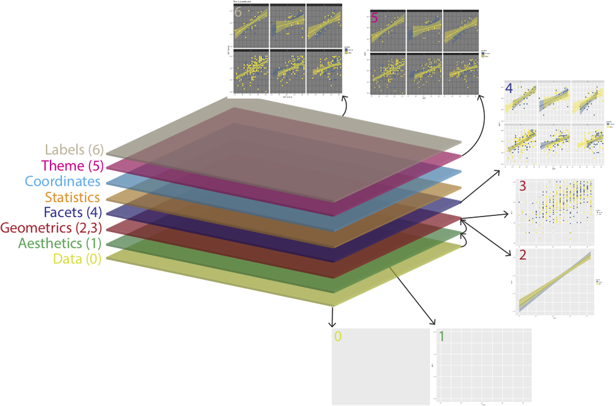

- **Layering is a key concept** in plotting with the ggplot2 package. That is, ggplot2 attempts to move users away from thinking about point and click interfaces that produce one single graphic. Instead, the hope is to give users the freedom to think about the graphics they would like to create in a highly customizable framework.
- ggplot2 has the desirable property of allowing users to use more **modular pieces of code** to create beautiful plots exactly to the user’s specification [1]
- You can read up on the Grammer of ggplot [here](https://psu-psychology.github.io/r-bootcamp-2019/talks/ggplot_grammar.html)

## **Creating a *ggplot***

In the very first step, we create a bar plot for variable education in dataset salary:

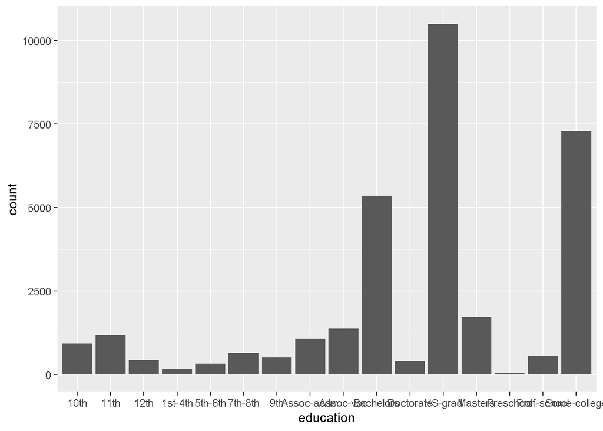

```r
ggplot(data = salary) +
  geom_bar(mapping = aes(x = education))
```

The plot shows the number of observations with respect to variable education.

With “ggplot2”, we initiate a plot with the function `ggplot()`, which creates a coordinate system that we can add layers to. The first argument of `ggplot()` is the dataset to use in the plot. So `ggplot(data = salary)` creates an empty plot based on data salary. It is empty because we have not specified

1. what type of plot we want to create and
2. which variable(s) should be used in the plot.

We complete our plot by **adding one or more layers** to `ggplot()`. The function `geom_bar()` adds a layer of bars to our plot, which creates a barplot. “ggplot2” comes with many geom functions that each add a different type of layer to a plot. We’ll learn a some of the most important layers of `ggplot()`.

- Each geom function in “ggplot2” takes a `mapping` argument.
  - This defines how variables in our dataset are mapped to visual properties. The `mapping` argument is always paired with `aes()`,
  - The `x` and `y` arguments of `aes()` specify which variables to map to the x and y axes (In many types of plots, including the barplot in our example, we could have only an `x` axis and no `y` axis).
  - “ggplot2” looks for the mapped variables in the `data` argument, in this case, `salary`.

Here is the basic structure of `ggplot()`:

```
ggplot(data = <DATA>) +
  <GEOM_FUNCTION>(mapping = aes(<MAPPINGS>)
```

We can also save the ggplot object for later use:

```r
p1 <- ggplot(data = salary)
```

And then we can just add the mapping to the ggplot object to create the plot:

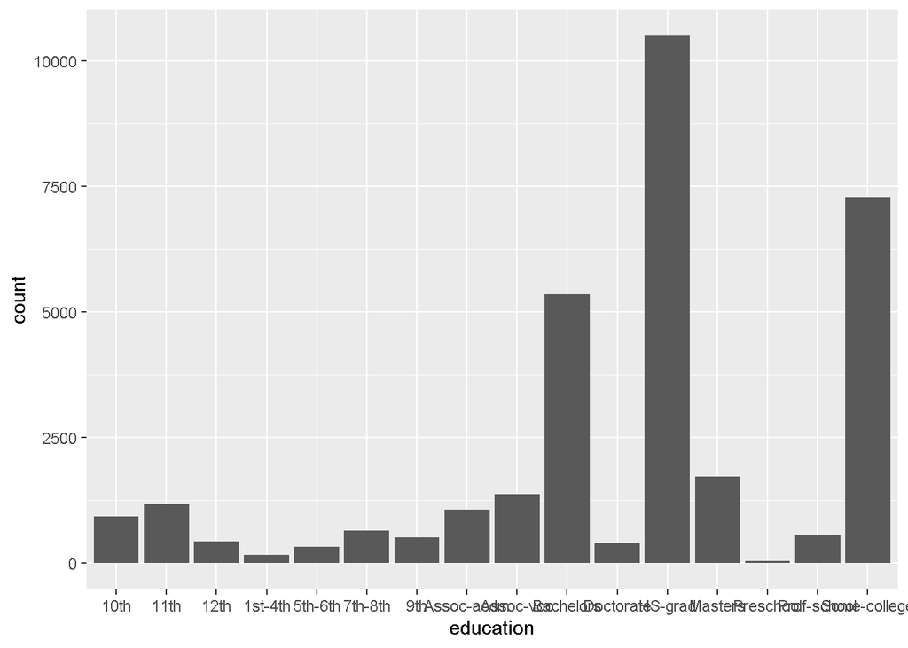

```r
p1 + geom_bar(mapping = aes(x = education))
```

This gets us a bar chart with no colors. It is still kind of a mess, but we have a plot. We can flip the coordinates of the plot to make it look better:

```r
p1 + geom_bar(mapping = aes(x = education)) + coord_flip()
```

[output not shown]

This way, we can see the categories of education better.

We can also **add another variable (“sex”)** as the color of the plot:

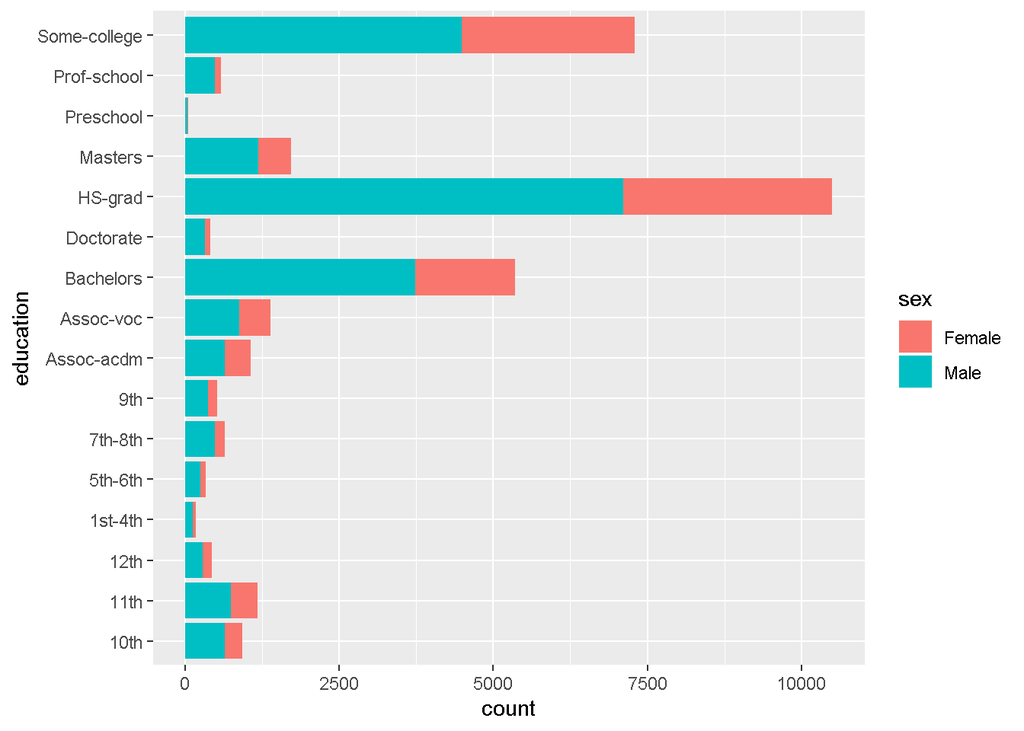

```r
p1 + geom_bar(mapping = aes(x = education, fill = sex)) + coord_flip()
```

Or, we could **add a title** to our plot:

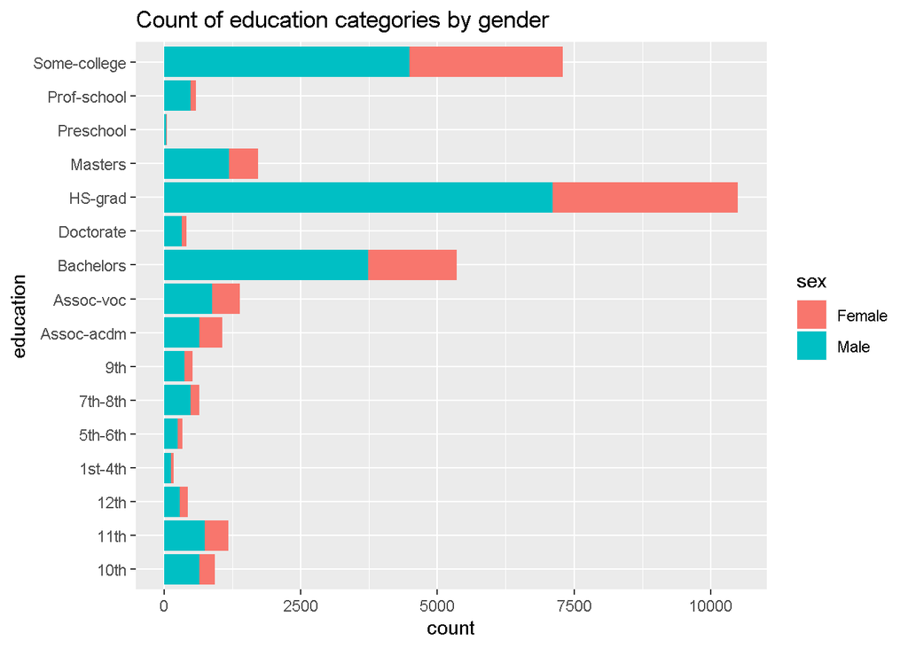

```r
p1 + geom_bar(mapping = aes(x = education, fill = sex)) + coord_flip() +
  ggtitle("Count of education categories by gender")
```

Now, let’s create different types of plots:

## **Histogram:**

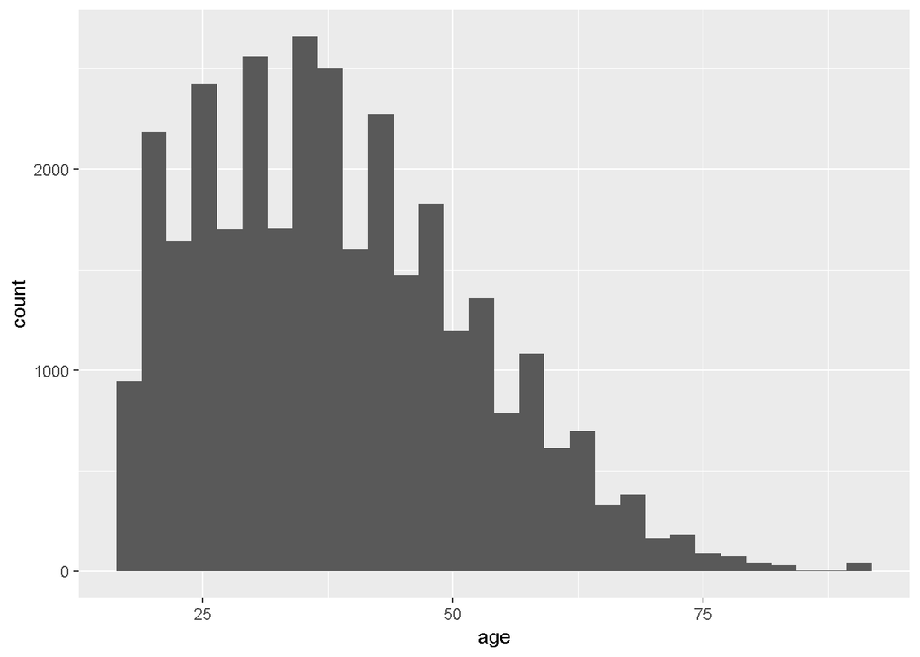

```r
p1 + geom_histogram(mapping = aes(x = age))
```

Now, let’s **change the binwidth** of the histogram:

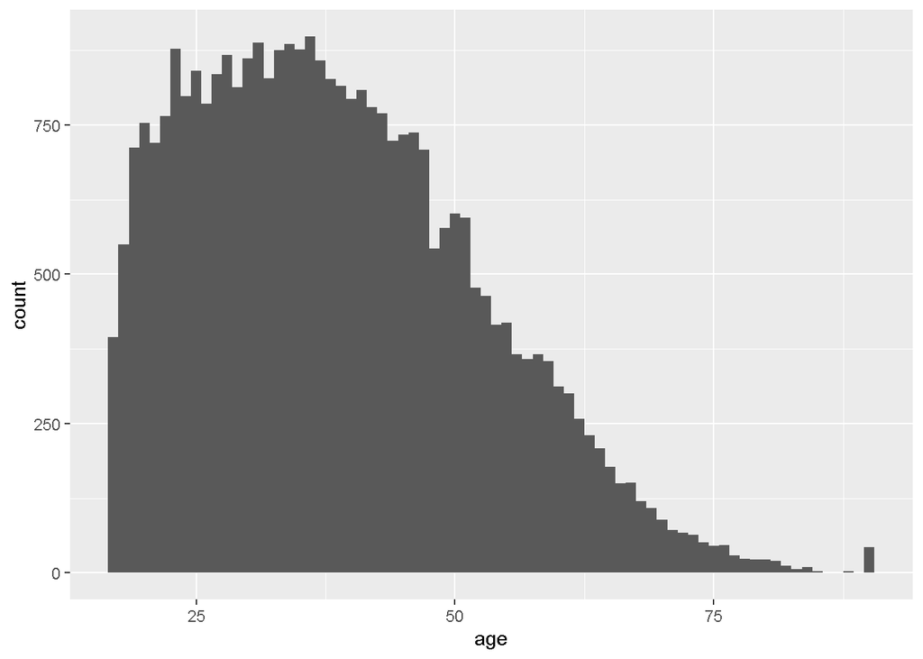

```r
p1 + geom_histogram(mapping = aes(x = age), binwidth = 1)
```

or again create the **plot by gender**:

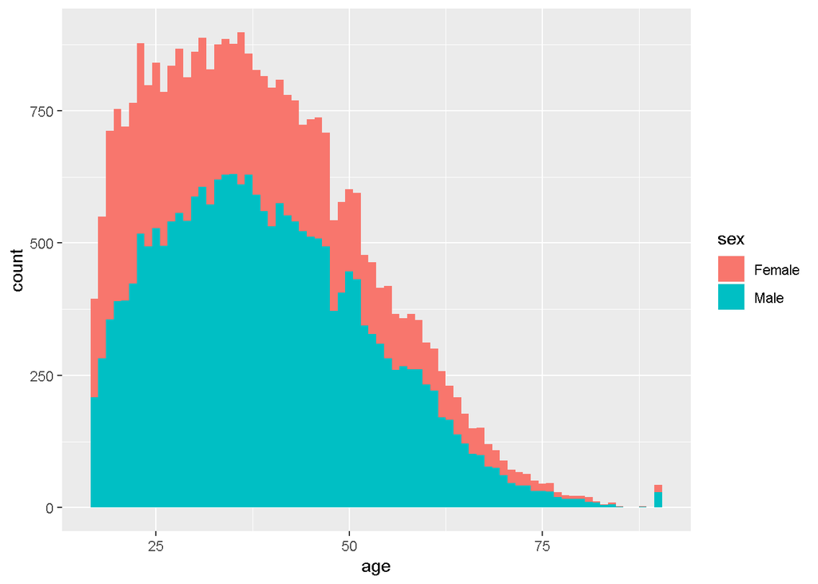

```r
p1 + geom_histogram(mapping = aes(x = age, fill = sex), binwidth = 1)
```

## **Scatterplot:**

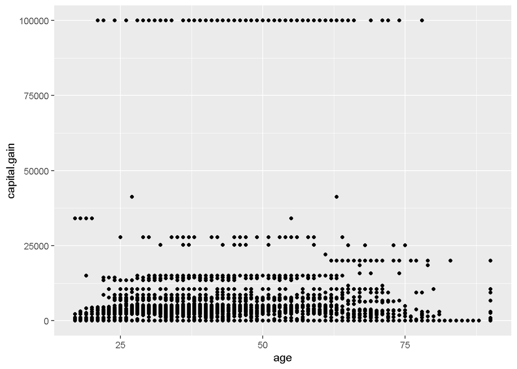

```r
p1 + geom_point(mapping = aes(x = age, y = capital.gain))
```

Separated by gender:

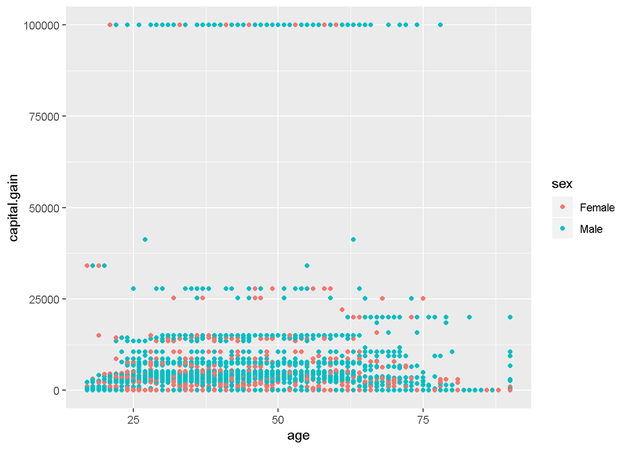

```r
p1 + geom_point(mapping = aes(x = age, y = capital.gain, colour = sex))
```

We can also **use contrast instead of color**. This is a good optin for differentiating the points based on a numeric variable:

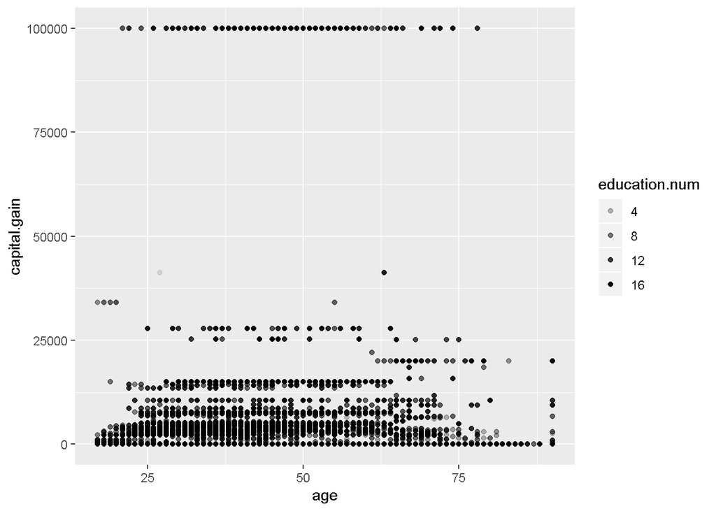

```r
# Left
p1 +
  geom_point(mapping = aes(x = age, y = capital.gain, alpha = education.num))
```

Instead of color, we could **change the size** of the data points in the scatterplot based on a variable:

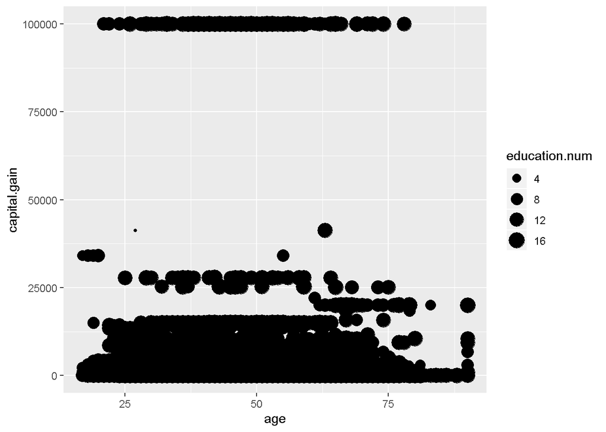

```r
p1 +
  geom_point(mapping = aes(x = age, y = capital.gain, size = education.num))
```

Or the shape:

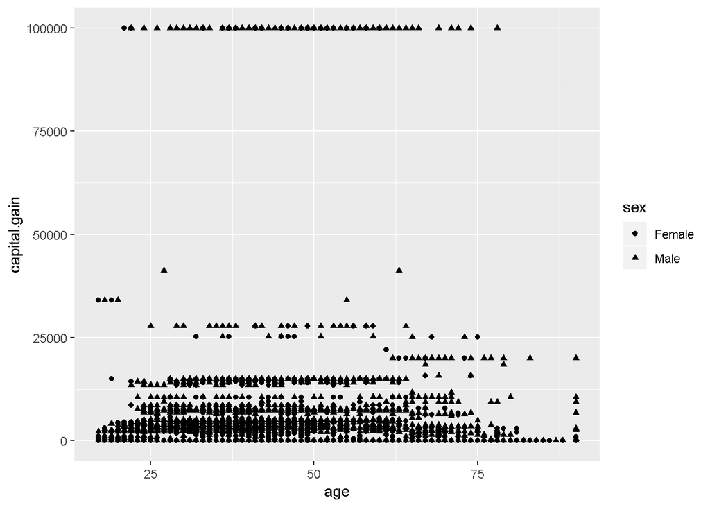

```r
p1 +
  geom_point(mapping = aes(x = age, y = capital.gain, shape = sex))
```

We can also use the same variable for both shape and color:

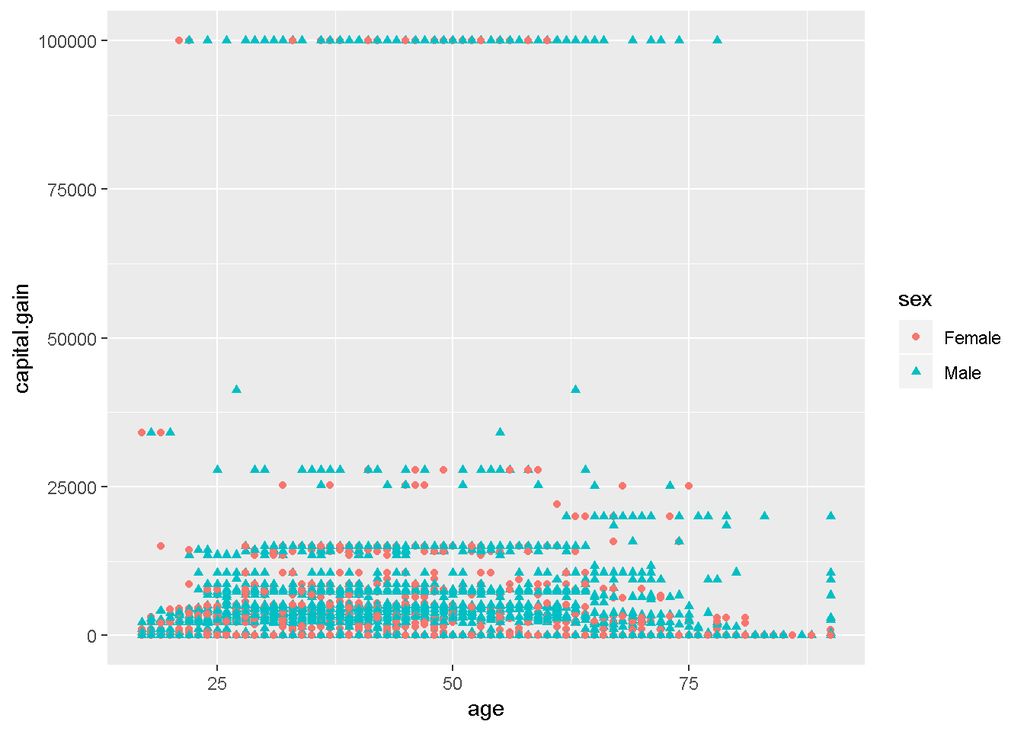

```r
p1 +
  geom_point(mapping = aes(x = age, y = capital.gain, shape = sex, colour = sex))
```

Or shape and contrast:

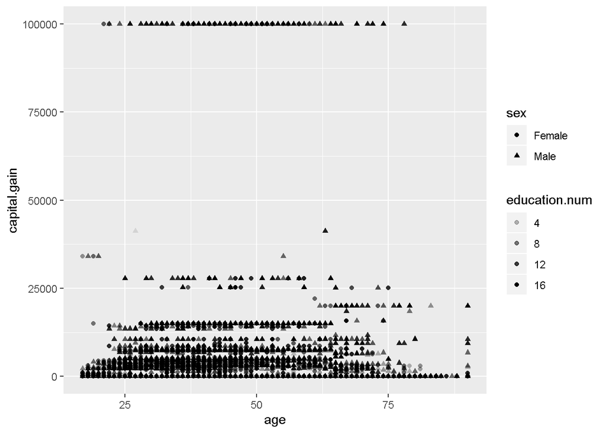

```r
p1 +
  geom_point(mapping = aes(x = age, y = capital.gain, alpha = education.num, shape = sex))
```

Another common type of plot is

## **Boxplot:**

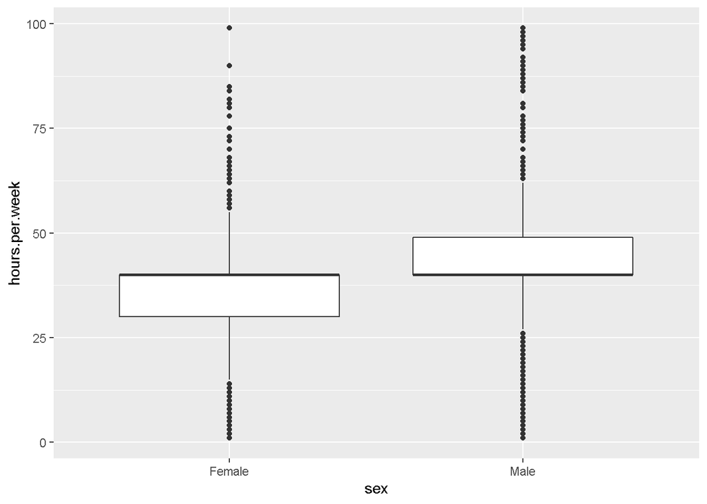

```r
p1 +
  geom_boxplot(mapping = aes(x = sex, y = hours.per.week))
```

We can remove the outliers from the boxplot by using argument outlier.shape:

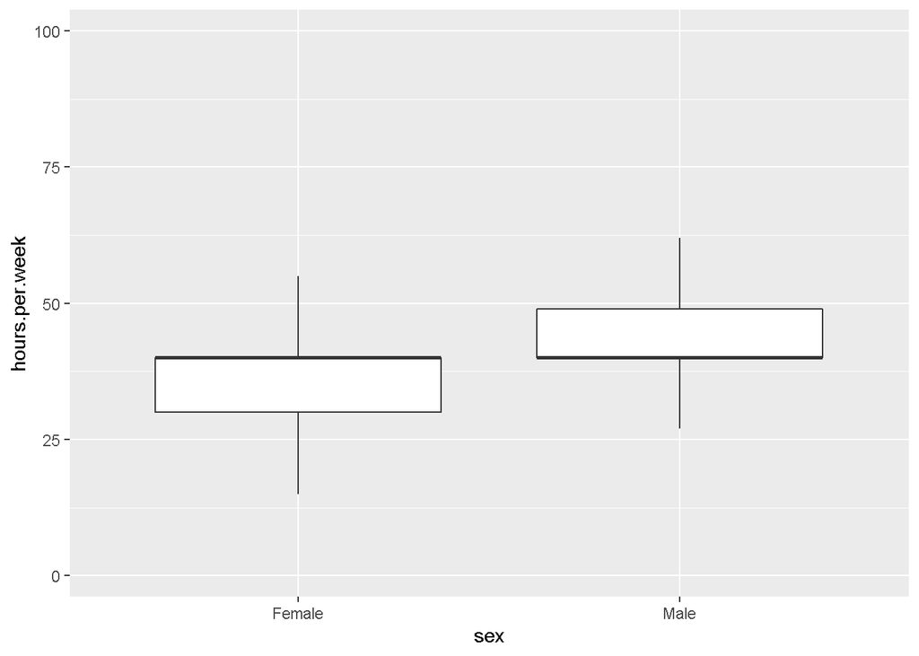

```r
p1 +
  geom_boxplot(mapping = aes(x = sex, y = hours.per.week), outlier.shape=NA)
```

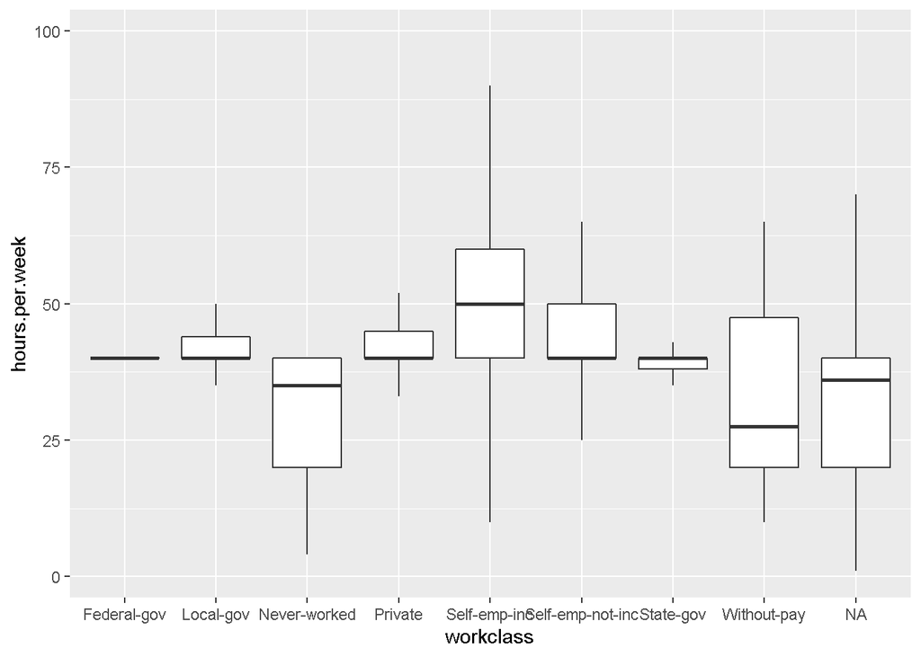

```r
p1 +
  geom_boxplot(mapping = aes(x = workclass, y = hours.per.week), outlier.shape=NA)
```

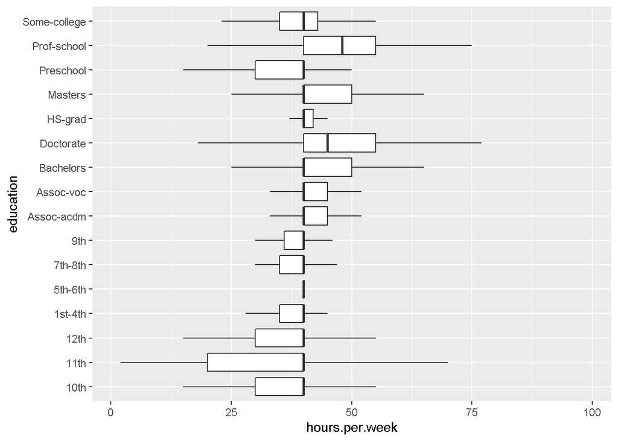

```r
p1 +
  geom_boxplot(mapping = aes(x = education, y = hours.per.week), outlier.shape=NA) +
  coord_flip()
```

We can use variable sex to color the visualization:

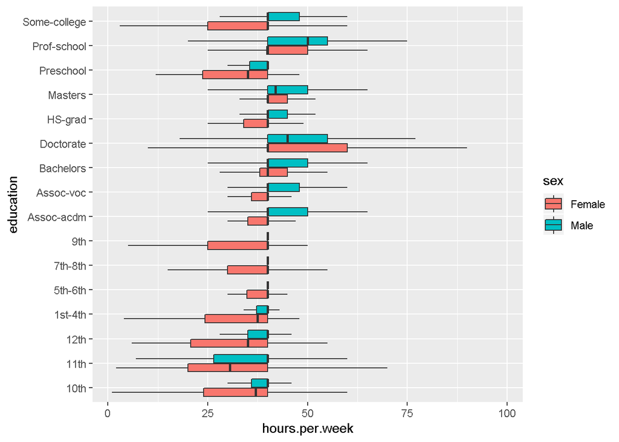

```r
p1 +
  geom_boxplot(mapping = aes(x = education, y = hours.per.week,
               fill = sex), outlier.shape=NA) +
  coord_flip()
```

Now we use salary.class to color the visualization:

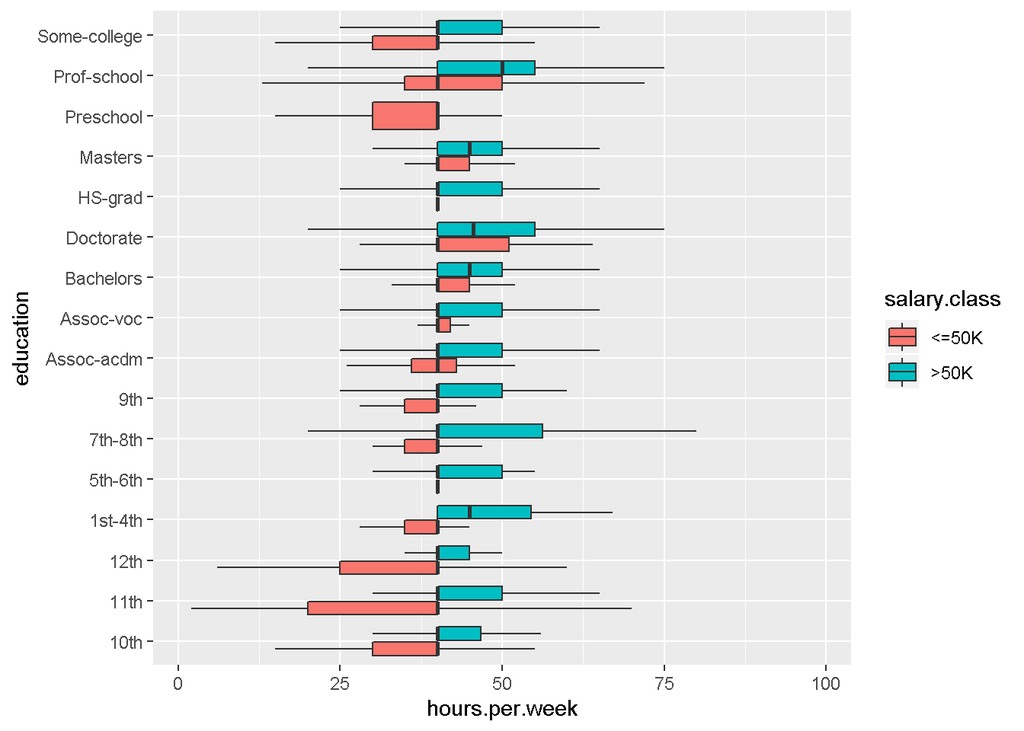

```r
p1 +
  geom_boxplot(mapping = aes(x = education, y = hours.per.week,
               fill = salary.class), outlier.shape=NA) +
  coord_flip()
```

We can modify the title of the coordinates:

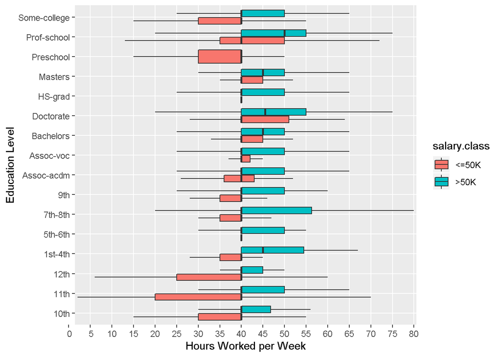

```r
p1 +
  geom_boxplot(mapping = aes(x = education, y = hours.per.week,
               fill = salary.class), outlier.shape=NA) +
  coord_flip() +
  scale_y_discrete(name ="Hours Worked per Week",
                    limits=seq(0,80,5)) +
  scale_x_discrete(name ="Education Level")
```

For a comprehensive list of plots we can create using ggplot2, please refer to: https://www.rstudio.com/wp-content/uploads/2015/03/ggplot2-cheatsheet.pdf

## **Facets**

One way to add additional variables is with aesthetics. Another way, particularly useful for categorical variables, is to split our plot into **facets**, subplots that each display one subset of the data.

To facet our plot by a single variable, use `facet_wrap()`. The first argument of `facet_wrap()` should be a formula, which we create with `~` followed by a variable name (here “formula” is the name of a data structure in R, not a synonym for “equation”). The variable that we pass to `facet_wrap()` should be discrete.

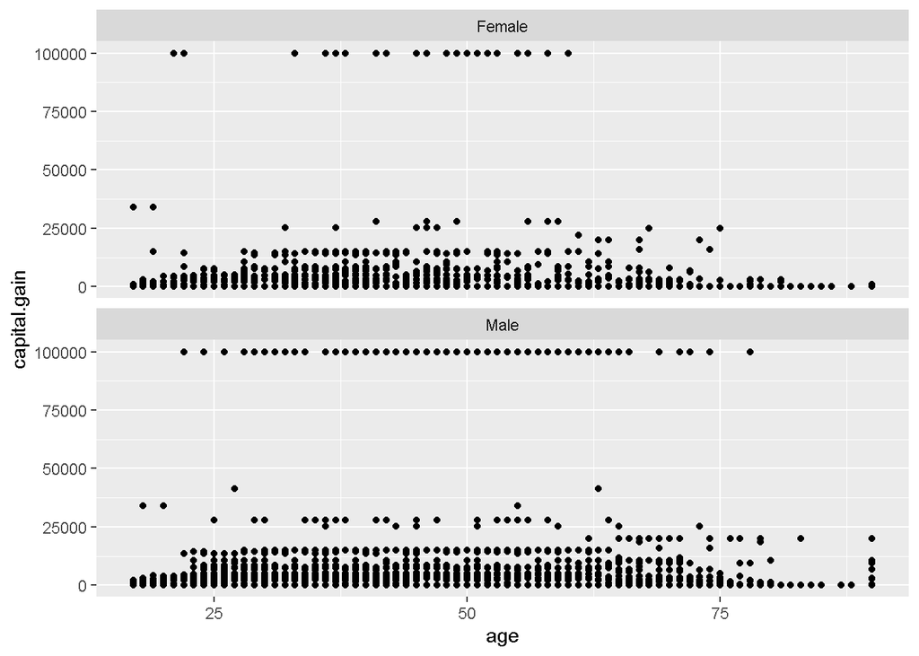

```r
p1 +
  geom_point(mapping = aes(x = age, y = capital.gain)) +
  facet_wrap(~ sex, nrow = 2)
```

To facet our plot on the combination of two variables, add `facet_grid()` to ourr plot call. The first argument of `facet_grid()` is also a formula. This time the formula should contain two variable names separated by a `~`.

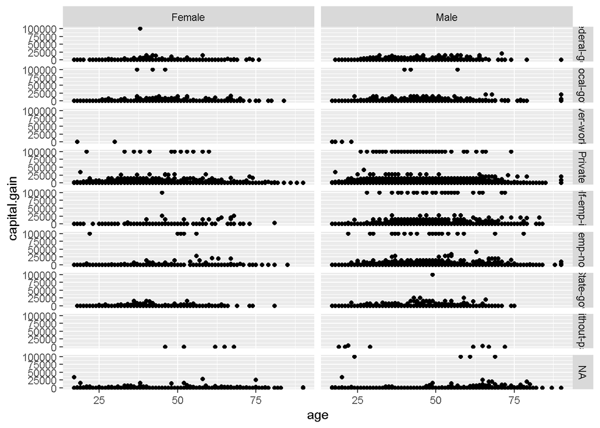

```r
p1 +
  geom_point(mapping = aes(x = age, y = capital.gain))  +
  facet_grid(workclass ~ sex)
```

If we prefer to not facet in the rows or columns dimension, use a `.` instead of a variable name, e.g. + `facet_grid(. ~ sex)`.

## **Geometric objects**

To change the geom in our plot, change the geom function that we add to `ggplot()`. For instance, to make the plots above, we can use this code:

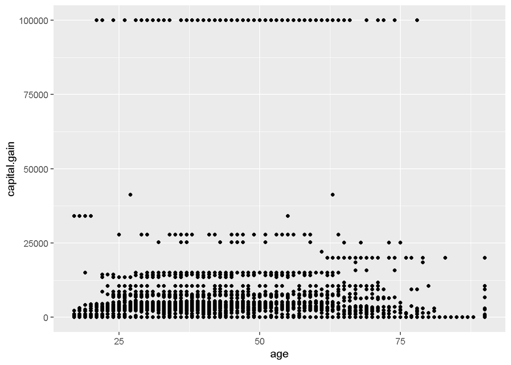

```r
# left
p1 +
  geom_point(mapping = aes(x = age, y = capital.gain))
```

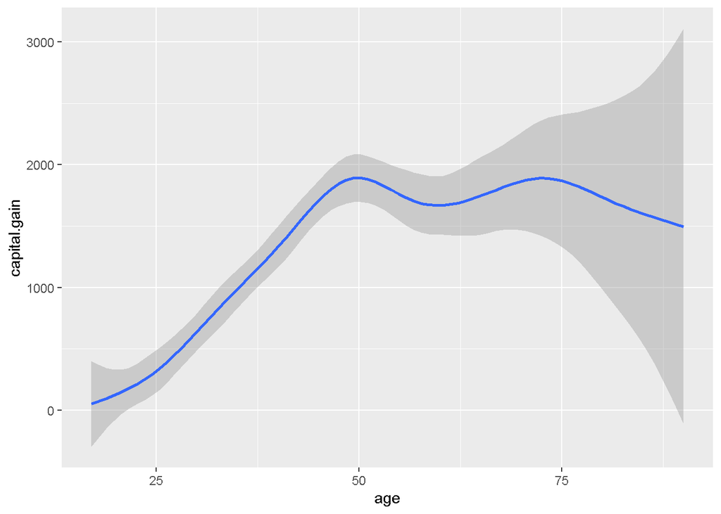

```r
# right
p1 +
  geom_smooth(mapping = aes(x = age, y = capital.gain))
```

Every geom function in “ggplot2” takes a `mapping` argument. However, not every aesthetic works with every geom. We could set the shape of a point, but we couldn’t set the “shape” of a line. On the other hand, we *could* set the linetype of a line. `geom_smooth()` will draw a different line, with a different linetype, for each unique value of the variable that we map to linetype.

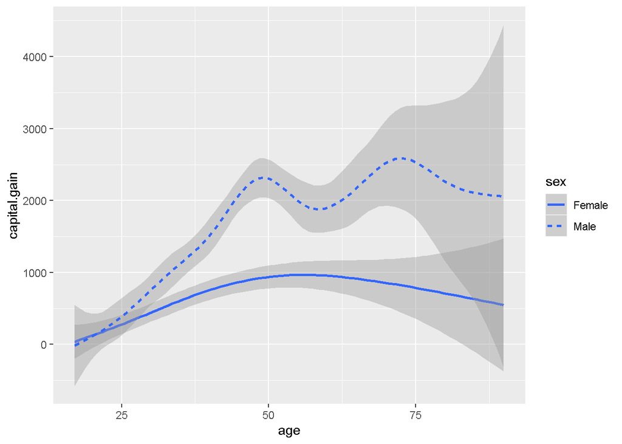

```r
p1 +
  geom_smooth(mapping = aes(x = age, y = capital.gain, linetype = sex))
```

Here `geom_smooth()` separates the observations into two lines based on their `sex` value.

“ggplot2” provides over 30 geoms, and extension packages provide even more (see https://www.ggplot2-exts.org for a sampling). The best way to get a comprehensive overview is the “ggplot2” cheatsheet, which we can find at http://rstudio.com/cheatsheets. To learn more about any single geom, use help: `?geom_smooth`.

Many geoms, like **`geom_smooth()`, use a single geometric object to display multiple rows of data**. For these geoms, we can set the `group` aesthetic to a categorical variable to draw multiple objects.

- “ggplot2” will draw a separate object for each unique value of the grouping variable.
- In practice, “ggplot2” will automatically group the data for these geoms whenever we map an aesthetic to a discrete variable (as in the `linetype` example).
- It is convenient to rely on this feature because the group aesthetic by itself does not add a legend or distinguishing features to the geoms.

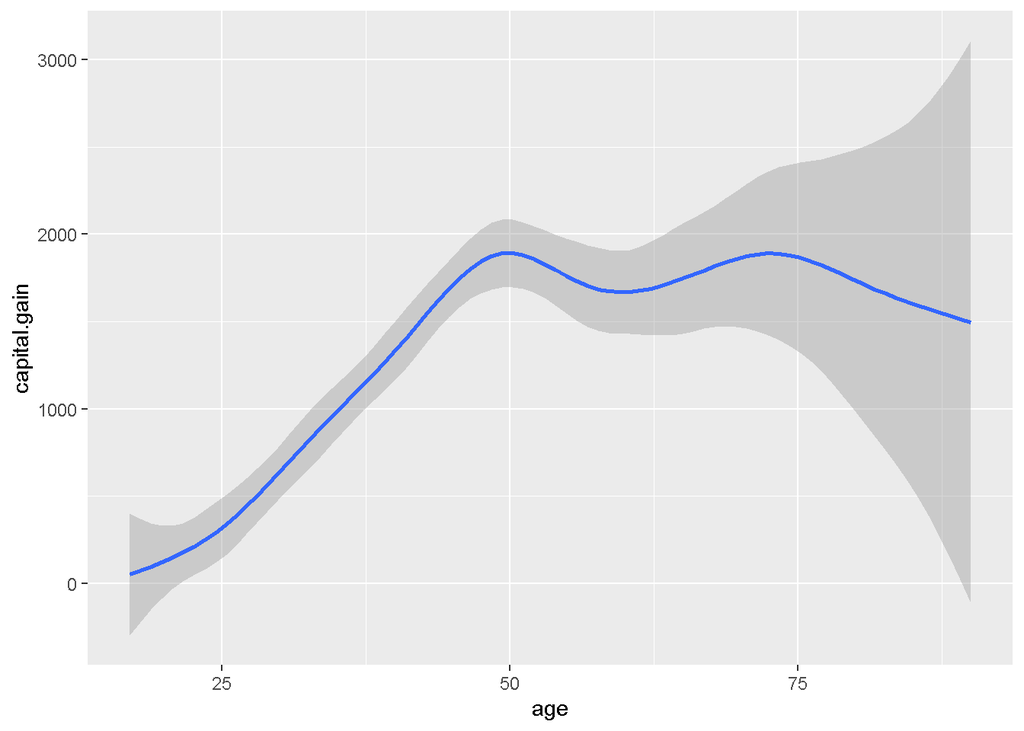

```r
p1 +
  geom_smooth(mapping = aes(x = age, y = capital.gain))
```

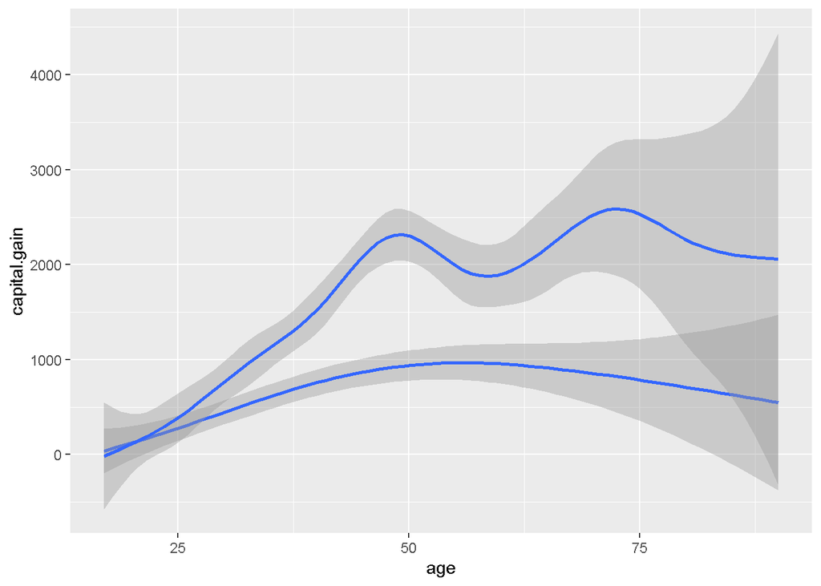

```r
p1 +
  geom_smooth(mapping = aes(x = age, y = capital.gain, group = sex))
```

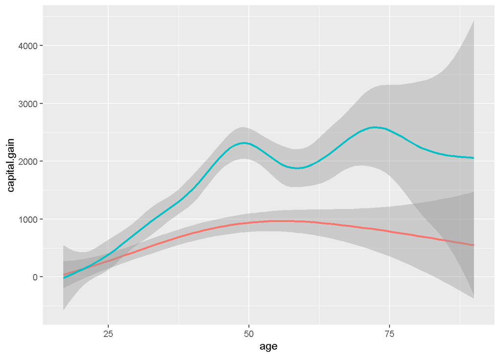

```r
p1 +
  geom_smooth(
    mapping = aes(x = age, y = capital.gain, color = sex),
    show.legend = FALSE
  )
```

To display multiple geoms in the same plot, add multiple geom functions to `ggplot()`:

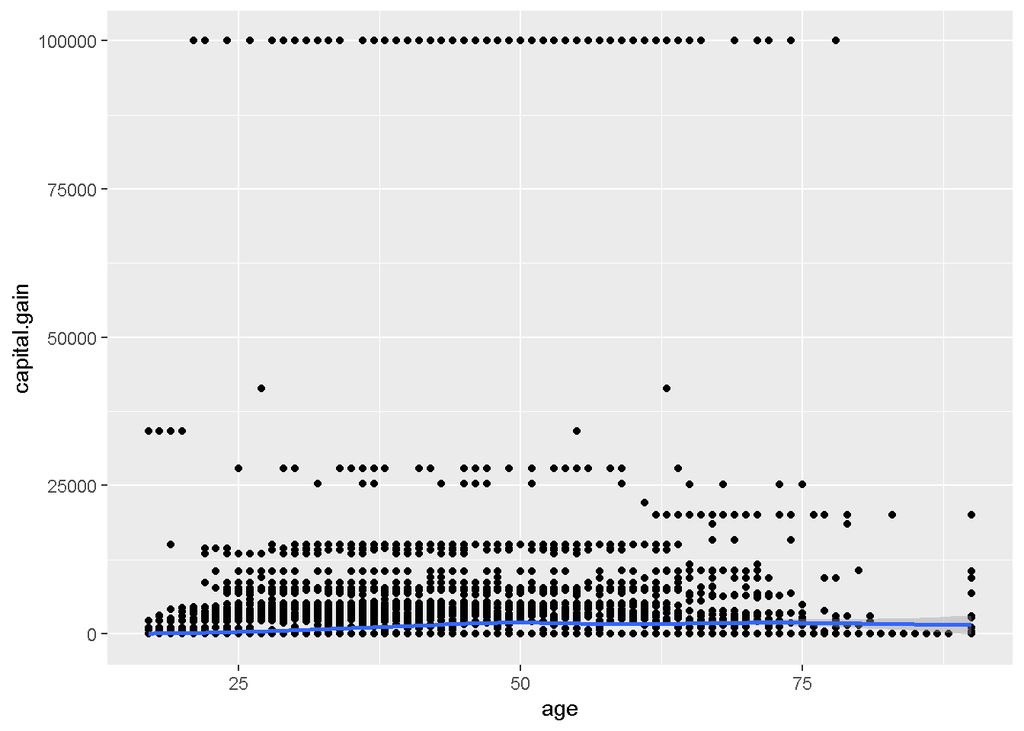

```r
p1 +
  geom_point(mapping = aes(x = age, y = capital.gain)) +
  geom_smooth(mapping = aes(x = age, y = capital.gain))
```

This, however, introduces some **duplication in our code**. Imagine if we wanted to change the y-axis to display another variable. We’d need to change the variable in two places, and we might forget to update one.